# Replication and Extension: Reducing Violence Against Women in Uganda through Video Dramas

Causal Inference in AI Models – Group Project

September Team - Ishika Narang, Yen Hsi Lo, Santiago Sierra

2026-03-11

# 1 Introduction

## 1.1 Paper Overview

We replicate and extend **“Reducing Violence Against Women in Uganda through Video Dramas: An Experimental Test to Illuminate Causal Mechanisms”** by Jasper Cooper, Donald P. Green, and Anna M. Wilke (American Economic Review Papers & Proceedings). The companion paper is **“Countering Violence Against Women by Encouraging Disclosure: A Mass Media Experiment in Rural Uganda”** (Comparative Political Studies, 2019).

## 1.2 Research Question

Can a mass media campaign — specifically, short anti-violence-against-women (anti-VAW) video vignettes screened at community film festivals — change attitudes toward VAW, encourage reporting of violent incidents, and ultimately reduce the occurrence of intimate partner violence in rural Uganda?

## 1.3 Experimental Design

The study is a **cluster-randomized controlled trial** conducted across 112 rural communities in central Uganda. Villages were organized into 16 geographic blocks and randomly assigned to one of seven conditions:

- **Anti-VAW only** (3 vignettes about domestic violence)
- **Anti-VAW + Abortion stigma** (combination)
- **Anti-VAW + Teacher absenteeism** (combination)
- Abortion stigma only
- Absenteeism only
- Abortion + Absenteeism
- **Placebo** (Hollywood films only, no vignettes)

For the main analysis, the first three conditions (all containing anti-VAW content) are the **treatment group** (IPV = 1), and the remaining four are the **control group** (IPV = 0).

Film festivals ran weekly from July 30 to September 4, 2016 (6 screenings per village). A **midline survey** was conducted in October 2016 (N = 5,344) and an **endline survey** in May 2017 (N = 1,035 compliers re-interviewed). The main analyses focus on **compliers**: respondents who attended at least one screening.

## 1.5 Our Approach

We replicate the key tables and figures from both papers, then **extend the analysis using causal forests** (Athey, Tibshirani & Wager, 2019) to explore treatment effect heterogeneity in a data-driven manner, and compare these findings to the paper’s subgroup analyses.

# 2 Setup

```r
# Required packages
required_packages <- c(
  "dplyr", "ggplot2", "lmtest", "sandwich",
  "stargazer", "MASS", "knitr", "kableExtra", "grf", "gridExtra"
)

# Install missing packages
new_packages <- required_packages[!(required_packages %in% installed.packages()[, "Package"])]
if (length(new_packages)) {
  install.packages(new_packages, repos = "https://cloud.r-project.org")
}

invisible(lapply(required_packages, library, character.only = TRUE))

# Ensure dplyr::select is not masked by MASS::select
select <- dplyr::select

# Define cluster.vcov as a wrapper around sandwich::vcovCL
# (the original code uses multiwayvcov::cluster.vcov, which gives equivalent results)
cluster.vcov <- function(model, cluster) {
  sandwich::vcovCL(model, cluster = cluster)
}

set.seed(123456789)
```

## 2.1 Load Data

We load the pre-built dataset from the replication package. This `.Rdata` file contains the full workspace after data cleaning, variable coding, imputation, and merging of midline into endline data.

```r
# Load the pre-built dataset
load("../Countering_VAW_replication/01_data/UG_VAW_data.Rdata")
```

## 2.2 Build Composite Indices

The following indices are constructed *after* the data is saved in the original pipeline, so we build them here.

```r
# --- Endline indices (from el data) ---

# Violence disapproval: average of ipv_attitude and disobey (both coded so higher = more disapproval)
el$violence_disapproval    <- (el$ipv_attitude + el$disobey) / 2
el$violence_disapproval_ml <- (el$ipv_attitude_ml + el$disobey_ml) / 2

# Intervention/reporting index: average of 4 reporting items
el$intervene_index    <- (el$involve_lc1 + el$involve_nabakyala +
                           el$involve_parents + el$report_police) / 4
el$intervene_index_ml <- (el$involve_lc1_ml + el$involve_nabakyala_ml +
                           el$involve_parents_ml + el$report_police_ml) / 4
# Combined midline-endline index
el$intervene_index_ml_3 <- (el$intervene_index + el$intervene_index_ml) / 2

# Any violence indicator
el$any_violence <- as.numeric(el$household_violence > 0)

# Community norms
el$violence_disapproval_comm <- (el$disobey_comm + el$ipv_norm) / 2

# Gender equality attitudes (endline)
el$support_gender_equality <- (el$boys_school_not_more_imp + el$able_marry +
                                el$father_not_final_say + el$men_should_participate) / 4

# Gender equality attitudes (midline, merged into el)
el$support_gender_equality_ml <- (el$not_better_man_achiever_ml +
                                   el$women_should_not_kneel_ml +
                                   el$woman_earns_no_problem_ml +
                                   el$women_better_leaders_ml) / 4

# Asset index (from midline variables)
el$asset_index <- (el$tv_ml + el$radio_ml + el$chair_ml + el$sofa_ml +
                    (1 - el$mud_wall_ml) + el$motor_cycle_ml) / 6

# --- Midline indices (from ml data) ---
ml$intervene_index     <- (ml$involve_lc1 + ml$involve_nabakyala +
                            ml$involve_parents + ml$report_police) / 4
ml$violence_disapproval <- (ml$ipv_attitude + ml$disobey) / 2
```

## 2.3 Load Lasso-Selected Covariates

The original paper uses LASSO to select covariates for each outcome, improving precision while maintaining unbiasedness. We load these pre-computed selections.

```r
# Source lasso utility functions
source("../Countering_VAW_replication/02_code/00_useful_functions/lasso_functions.R")

# Load lasso-selected covariates
lasso_available <- tryCatch({
  load("../Countering_VAW_replication/01_data/lasso_selected_covariates.Rdata")
  TRUE
}, error = function(e) {
  message("Could not load lasso covariates: ", e$message)
  FALSE
})

if (lasso_available) {
  # Check which lasso objects are available
  lasso_objs <- ls(pattern = "lasso")
  cat("Available lasso objects:", paste(lasso_objs, collapse = ", "), "\n")
}
```

```
## Available lasso objects: IPV_lasso_covariates_M, IPV_lasso_covariates_panel_M, IPV_lasso_covariates_panel_W, IPV_lasso_covariates_W, lasso_available, lasso_with_best_lambda, run_lasso_get_variables
```

## 2.4 Define Analysis Functions

We define helper functions that mirror the original analysis pipeline: OLS regression with block fixed effects and cluster-robust standard errors.

```r
#' OLS with block fixed effects and cluster-robust SEs
#'
#' Replicates the ols_main() function from the original code.
#' Specification: outcome ~ treatment + block_FE + resample + n_end_mean [+ covariates]
#' Standard errors clustered at the village (tc_id) level.
run_ols <- function(outcome, treatment = "IPV", data, covariates = NULL,
                    cluster_var = "tc_id") {

  # Build formula
  fe <- "as.factor(block_id) + resample + n_end_mean"
  if (!is.null(covariates) && length(covariates) > 0) {
    valid_covs <- covariates[covariates %in% names(data)]
    if (length(valid_covs) > 0) {
      fe <- paste(fe, "+", paste(valid_covs, collapse = " + "))
    }
  }
  fml <- as.formula(paste(outcome, "~", treatment, "+", fe))

  # Fit model
  fit <- lm(fml, data = data)

  # Cluster-robust variance-covariance matrix
  vcov_cl <- cluster.vcov(model = fit, cluster = data[[cluster_var]])
  ct <- coeftest(fit, vcov. = vcov_cl)

  list(
    fit        = fit,
    coeftest   = ct,
    estimate   = ct[treatment, "Estimate"],
    se         = ct[treatment, "Std. Error"],
    pval       = ct[treatment, "Pr(>|t|)"],
    n          = sum(complete.cases(data[, c(outcome, treatment)])),
    n_clusters = length(unique(data[[cluster_var]][!is.na(data[[outcome]])]))
  )
}

#' OLS for village-level regressions (no resample, no clustered SEs)
#' Village-level data has one observation per village, so no clustering needed.
run_ols_village <- function(outcome, treatment = "IPV", data) {
  fml <- as.formula(paste(outcome, "~", treatment, "+ as.factor(block_id) + n_end_mean"))
  fit <- lm(fml, data = data)
  ct <- coeftest(fit)
  list(
    fit      = fit,
    coeftest = ct,
    estimate = ct[treatment, "Estimate"],
    se       = ct[treatment, "Std. Error"],
    pval     = ct[treatment, "Pr(>|t|)"],
    n        = nobs(fit)
  )
}

#' Compute control group mean for an outcome
ctrl_mean <- function(outcome, data, treatment = "IPV") {
  mean(data[[outcome]][data[[treatment]] == 0], na.rm = TRUE)
}

#' Try to get lasso-selected covariates for an outcome
get_lasso_covs <- function(outcome_name, lasso_list_name) {
  if (!lasso_available) return(NULL)
  lasso_list <- tryCatch(get(lasso_list_name), error = function(e) NULL)
  if (is.null(lasso_list)) return(NULL)
  tryCatch(prep_covariates(outcome_name, lasso_list), error = function(e) NULL)
}
```

# 3 Data Overview

```r
# Define analysis samples
compliers       <- subset(el, respondent_category == "Complier")
women_compliers <- subset(el, respondent_category == "Complier" & female == 1)
men_compliers   <- subset(el, respondent_category == "Complier" & female == 0)
all_women       <- subset(el, female == 1)

sample_info <- data.frame(
  Sample = c("Total endline respondents", "Compliers (panel)",
             "Women compliers", "Men compliers",
             "All women (endline)",
             "Villages in analysis", "Treatment villages (IPV=1)",
             "Control villages (IPV=0)", "Randomization blocks"),
  N = c(nrow(el), nrow(compliers),
        nrow(women_compliers), nrow(men_compliers),
        nrow(all_women),
        length(unique(compliers$tc_id)),
        sum(treatment_assignment$IPV),
        sum(1 - treatment_assignment$IPV),
        length(unique(compliers$block_id)))
)

kable(sample_info, col.names = c("", "N"), caption = "Sample Sizes") %>%
  kable_styling(bootstrap_options = c("striped", "hover"), full_width = FALSE)
```

Sample Sizes

|  | N |
| --- | --- |
| Total endline respondents | 1956 |
| Compliers (panel) | 1041 |
| Women compliers | 321 |
| Men compliers | 720 |
| All women (endline) | 1036 |
| Villages in analysis | 110 |
| Treatment villages (IPV=1) | 48 |
| Control villages (IPV=0) | 64 |
| Randomization blocks | 16 |

The treatment group comprises villages assigned to any condition containing anti-VAW vignettes (IPV-only, IPV+abortion, IPV+absenteeism). The control group includes all other conditions. Villages are organized into 16 geographic blocks to minimize within-block variance.

```r
# Treatment balance across key covariates
balance_vars <- c("female", "age_ml", "married_ml", "highest_grade_ml",
                  "household_head_ml", "members_ml", "number_children_ml")
balance_vars <- balance_vars[balance_vars %in% names(compliers)]

if (length(balance_vars) > 0) {
  balance_table <- do.call(rbind, lapply(balance_vars, function(v) {
    t_mean <- mean(compliers[[v]][compliers$IPV == 1], na.rm = TRUE)
    c_mean <- mean(compliers[[v]][compliers$IPV == 0], na.rm = TRUE)
    diff   <- t_mean - c_mean
    # t-test for difference
    tt <- tryCatch(
      t.test(compliers[[v]][compliers$IPV == 1],
             compliers[[v]][compliers$IPV == 0])$p.value,
      error = function(e) NA
    )
    data.frame(Variable = v, Treatment = round(t_mean, 3),
               Control = round(c_mean, 3), Difference = round(diff, 3),
               P_value = round(tt, 3))
  }))

  kable(balance_table,
        caption = "Balance Check: Treatment vs Control (Complier Panel)",
        col.names = c("Variable", "Treatment Mean", "Control Mean",
                       "Difference", "p-value")) %>%
    kable_styling(bootstrap_options = c("striped", "hover"), full_width = FALSE)
}
```

Balance Check: Treatment vs Control (Complier Panel)

| Variable | Treatment Mean | Control Mean | Difference | p-value |
| --- | --- | --- | --- | --- |
| female | 0.332 | 0.290 | 0.042 | 0.153 |
| age_ml | 29.783 | 29.443 | 0.340 | 0.501 |
| married_ml | 0.303 | 0.384 | -0.081 | 0.006 |
| highest_grade_ml | 6.814 | 6.913 | -0.099 | 0.648 |
| household_head_ml | 0.684 | 0.679 | 0.005 | 0.877 |
| members_ml | 4.150 | 4.204 | -0.053 | 0.730 |
| number_children_ml | 3.502 | 3.455 | 0.047 | 0.822 |

# 4 Replication of Main Results

## 4.1 Reporting Attitudes — Women (CPS Table 1)

This is the paper’s central finding. We estimate the effect of the anti-VAW campaign on women’s willingness to report hypothetical incidents of domestic violence to various authorities: parents, the village women’s counselor (*Nabakyala*), the local council chairperson (LC1), and the police. We also report effects on a composite intervention index (average of the four items).

The specification is:
$$Y_{ij} = \beta
\cdot \text{IPV}_j + \gamma \cdot X_{ij} + \delta_b + \alpha \cdot
\text{resample}_{ij} + \phi \cdot \overline{N}_j +
\varepsilon_{ij}$$

where $j$ indexes villages, $b$ indexes blocks, $\delta_b$ are block fixed effects, $\overline{N}_j$ is the average audience size, and standard errors are clustered at the village level.

```r
outcomes_report <- c("involve_parents", "involve_nabakyala",
                     "involve_lc1", "report_police", "intervene_index")
outcome_labels  <- c("Involve Parents", "Involve Nabakyala",
                     "Involve LC1", "Report Police", "Intervention Index")

# Run regressions for midline and endline
fits_w_ml <- list()
fits_w_el <- list()

for (out in outcomes_report) {
  out_ml <- paste0(out, "_ml")

  # Get lasso covariates (midline uses _W list, endline uses _panel_W list)
  covs_ml <- get_lasso_covs(out, "IPV_lasso_covariates_W")
  covs_el <- get_lasso_covs(out, "IPV_lasso_covariates_panel_W")

  fits_w_ml[[out]] <- run_ols(out_ml, data = women_compliers, covariates = covs_ml)
  fits_w_el[[out]] <- run_ols(out,    data = women_compliers, covariates = covs_el)
}

# Build results table
women_results <- data.frame(
  Outcome = rep(outcome_labels, each = 2),
  Wave    = rep(c("Midline", "Endline"), length(outcomes_report)),
  Coef    = unlist(lapply(outcomes_report, function(o)
    c(fits_w_ml[[o]]$estimate, fits_w_el[[o]]$estimate))),
  SE      = unlist(lapply(outcomes_report, function(o)
    c(fits_w_ml[[o]]$se, fits_w_el[[o]]$se))),
  P_value = unlist(lapply(outcomes_report, function(o)
    c(fits_w_ml[[o]]$pval, fits_w_el[[o]]$pval))),
  Ctrl_Mean = unlist(lapply(outcomes_report, function(o) {
    out_ml <- paste0(o, "_ml")
    c(ctrl_mean(out_ml, women_compliers), ctrl_mean(o, women_compliers))
  })),
  N = unlist(lapply(outcomes_report, function(o)
    c(fits_w_ml[[o]]$n, fits_w_el[[o]]$n)))
)

# Add significance stars
women_results$Stars <- ifelse(women_results$P_value < 0.01, "***",
                       ifelse(women_results$P_value < 0.05, "**",
                       ifelse(women_results$P_value < 0.1, "*", "")))

# Format for display
women_display <- women_results %>%
  mutate(
    Estimate = paste0(round(Coef, 3), Stars, "<br>(", round(SE, 3), ")"),
    `Control Mean` = round(Ctrl_Mean, 3)
  ) %>%
  select(Outcome, Wave, Estimate, `Control Mean`, N)

kable(women_display,
      caption = "Effect of Anti-VAW Campaign on Women's Reporting Attitudes (Complier Panel)",
      align = c("l", "l", "r", "r", "r"),
      escape = FALSE) %>%
  kable_styling(bootstrap_options = c("striped", "hover", "condensed"),
                full_width = FALSE) %>%
  footnote(general = "OLS with block FE, cluster-robust SEs (village level). * p<0.1, ** p<0.05, *** p<0.01.")
```

Effect of Anti-VAW Campaign on Women’s Reporting Attitudes (Complier Panel)

| Outcome | Wave | Estimate | Control Mean | N |
| --- | --- | --- | --- | --- |
| Involve Parents | Midline | 0.094*<br>(0.056) | 0.462 | 321 |
| Involve Parents | Endline | 0.144***<br>(0.053) | 0.439 | 321 |
| Involve Nabakyala | Midline | 0.076<br>(0.056) | 0.579 | 321 |
| Involve Nabakyala | Endline | 0.158***<br>(0.058) | 0.520 | 321 |
| Involve LC1 | Midline | 0.058<br>(0.049) | 0.222 | 321 |
| Involve LC1 | Endline | 0.041<br>(0.055) | 0.409 | 321 |
| Report Police | Midline | 0.096**<br>(0.039) | 0.158 | 321 |
| Report Police | Endline | 0.13***<br>(0.048) | 0.205 | 321 |
| Intervention Index | Midline | 0.085***<br>(0.03) | 0.355 | 321 |
| Intervention Index | Endline | 0.126***<br>(0.035) | 0.393 | 321 |

Note:  
OLS with block FE, cluster-robust SEs (village level). * p<0.1, ** p<0.05, *** p<0.01.

**Comparison with CPS Table 1 (Women Compliers, N~321)**:

| Outcome | Wave | Paper Coef (SE) | Paper Ctrl Mean |
| --- | --- | --- | --- |
| Involve Parents | Midline | 0.070* (0.040) | 0.41 |
| Involve Parents | Endline | 0.172*** (0.050) | 0.40 |
| Involve Nabakyala | Midline | 0.098** (0.041) | 0.40 |
| Involve Nabakyala | Endline | 0.119** (0.054) | 0.36 |
| Involve LC1 | Midline | 0.104*** (0.038) | 0.38 |
| Involve LC1 | Endline | 0.097** (0.049) | 0.31 |
| Report Police | Midline | 0.067 (0.042) | 0.38 |
| Report Police | Endline | 0.117** (0.048) | 0.37 |
| Intervention Index | Midline | 0.085*** (0.030) | 0.39 |
| Intervention Index | Endline | 0.126*** (0.035) | 0.36 |

# 5 Check this 👆🏻

## 5.1 Reporting Attitudes — Men (CPS Table 2)

We replicate the same analysis for male compliers.

```r
fits_m_ml <- list()
fits_m_el <- list()

for (out in outcomes_report) {
  out_ml <- paste0(out, "_ml")

  covs_ml <- get_lasso_covs(out, "IPV_lasso_covariates_M")
  covs_el <- get_lasso_covs(out, "IPV_lasso_covariates_panel_M")

  fits_m_ml[[out]] <- run_ols(out_ml, data = men_compliers, covariates = covs_ml)
  fits_m_el[[out]] <- run_ols(out,    data = men_compliers, covariates = covs_el)
}

men_results <- data.frame(
  Outcome = rep(outcome_labels, each = 2),
  Wave    = rep(c("Midline", "Endline"), length(outcomes_report)),
  Coef    = unlist(lapply(outcomes_report, function(o)
    c(fits_m_ml[[o]]$estimate, fits_m_el[[o]]$estimate))),
  SE      = unlist(lapply(outcomes_report, function(o)
    c(fits_m_ml[[o]]$se, fits_m_el[[o]]$se))),
  P_value = unlist(lapply(outcomes_report, function(o)
    c(fits_m_ml[[o]]$pval, fits_m_el[[o]]$pval))),
  Ctrl_Mean = unlist(lapply(outcomes_report, function(o) {
    out_ml <- paste0(o, "_ml")
    c(ctrl_mean(out_ml, men_compliers), ctrl_mean(o, men_compliers))
  })),
  N = unlist(lapply(outcomes_report, function(o)
    c(fits_m_ml[[o]]$n, fits_m_el[[o]]$n)))
)

men_results$Stars <- ifelse(men_results$P_value < 0.01, "***",
                    ifelse(men_results$P_value < 0.05, "**",
                    ifelse(men_results$P_value < 0.1, "*", "")))

men_display <- men_results %>%
  mutate(
    Estimate = paste0(round(Coef, 3), Stars, "<br>(", round(SE, 3), ")"),
    `Control Mean` = round(Ctrl_Mean, 3)
  ) %>%
  select(Outcome, Wave, Estimate, `Control Mean`, N)

kable(men_display,
      caption = "Effect of Anti-VAW Campaign on Men's Reporting Attitudes (Complier Panel)",
      align = c("l", "l", "r", "r", "r"),
      escape = FALSE) %>%
  kable_styling(bootstrap_options = c("striped", "hover", "condensed"),
                full_width = FALSE) %>%
  footnote(general = "OLS with block FE, cluster-robust SEs (village level). * p<0.1, ** p<0.05, *** p<0.01.")
```

Effect of Anti-VAW Campaign on Men’s Reporting Attitudes (Complier Panel)

| Outcome | Wave | Estimate | Control Mean | N |
| --- | --- | --- | --- | --- |
| Involve Parents | Midline | 0.082**<br>(0.035) | 0.493 | 720 |
| Involve Parents | Endline | 0.038<br>(0.035) | 0.502 | 720 |
| Involve Nabakyala | Midline | 0.032<br>(0.038) | 0.612 | 720 |
| Involve Nabakyala | Endline | 0.057*<br>(0.034) | 0.610 | 720 |
| Involve LC1 | Midline | 0.021<br>(0.033) | 0.285 | 720 |
| Involve LC1 | Endline | 0.043<br>(0.034) | 0.356 | 720 |
| Report Police | Midline | -0.041<br>(0.025) | 0.203 | 720 |
| Report Police | Endline | 0.034<br>(0.032) | 0.227 | 720 |
| Intervention Index | Midline | 0.02<br>(0.019) | 0.398 | 720 |
| Intervention Index | Endline | 0.043*<br>(0.025) | 0.424 | 720 |

Note:  
OLS with block FE, cluster-robust SEs (village level). * p<0.1, ** p<0.05, *** p<0.01.

**Comparison with CPS Table 2 (Men Compliers, N~720)**:

| Outcome | Wave | Paper Coef (SE) | Paper Ctrl Mean |
| --- | --- | --- | --- |
| Involve Parents | Midline | 0.004 (0.029) | 0.42 |
| Involve Parents | Endline | 0.043 (0.039) | 0.42 |
| Involve Nabakyala | Midline | 0.019 (0.030) | 0.42 |
| Involve Nabakyala | Endline | 0.039 (0.039) | 0.39 |
| Involve LC1 | Midline | 0.027 (0.023) | 0.44 |
| Involve LC1 | Endline | 0.045 (0.030) | 0.40 |
| Report Police | Midline | 0.032 (0.024) | 0.41 |
| Report Police | Endline | 0.046 (0.033) | 0.38 |
| Intervention Index | Midline | 0.020 (0.019) | 0.42 |
| Intervention Index | Endline | 0.043* (0.025) | 0.40 |

## 5.2 Victimization (CPS Table 4)

We test whether the increased willingness to report translates into actual reductions in violence. We examine three outcomes measured at endline among women: (1) the *number* of violence incidents (`household_violence`), (2) the *probability* of any incident (`any_violence`), and (3) the *frequency* of incidents (`household_violence_frequency`, analyzed with ordered probit). Analyses are conducted at both the village level (aggregating to cluster means) and the individual level.

```r
# --- Village-level analysis ---
# Collapse to village means for ALL women (not just compliers), matching original code
vict_village <- el %>%
  filter(female == 1) %>%
  group_by(tc_id, block_id, IPV) %>%
  summarise(
    household_violence = mean(household_violence, na.rm = TRUE),
    any_violence       = mean(any_violence, na.rm = TRUE),
    household_violence_frequency = mean(household_violence_frequency, na.rm = TRUE),
    n_end_mean         = first(n_end_mean),
    .groups = "drop"
  )

# Village-level OLS (no resample, regular SEs — one obs per village)
vict_vill_hv <- run_ols_village("household_violence", data = vict_village)
vict_vill_av <- run_ols_village("any_violence", data = vict_village)

# --- Individual-level analysis: all women ---
vict_ind_hv_all <- run_ols("household_violence", data = all_women)
vict_ind_av_all <- run_ols("any_violence", data = all_women)

# --- Individual-level analysis: women compliers ---
vict_ind_hv_comp <- run_ols("household_violence", data = women_compliers)
vict_ind_av_comp <- run_ols("any_violence", data = women_compliers)

# --- Ordered probit for violence frequency (Table 4, columns 7-8) ---
run_ordered_probit <- function(data, label) {
  tryCatch({
    fit <- polr(as.factor(household_violence_frequency) ~ IPV + resample +
                  as.factor(block_id) + n_end_mean,
                method = "probit", data = data, Hess = TRUE)
    vcov_cl <- sandwich::vcovCL(fit, cluster = data$tc_id)
    ct <- coeftest(fit, vcov. = vcov_cl)
    list(fit = fit, coeftest = ct,
         estimate = ct["IPV", "Estimate"],
         se = ct["IPV", "Std. Error"],
         pval = ct["IPV", "Pr(>|z|)"],
         n = nobs(fit))
  }, error = function(e) {
    message("Ordered probit failed for ", label, ": ", e$message)
    list(estimate = NA, se = NA, pval = NA, n = NA)
  })
}

oprobit_all  <- run_ordered_probit(all_women, "all women")
oprobit_comp <- run_ordered_probit(women_compliers, "women compliers")

# Build victimization results table
vict_table <- data.frame(
  Outcome = c(rep("# Incidents (OLS)", 3),
              rep("Any Violence (OLS)", 3),
              rep("Violence Frequency (Ordered Probit)", 2)),
  Sample  = c("Village (All W)", "Indiv. (All W)", "Indiv. (W Compl.)",
              "Village (All W)", "Indiv. (All W)", "Indiv. (W Compl.)",
              "Indiv. (All W)", "Indiv. (W Compl.)"),
  Coef    = c(vict_vill_hv$estimate, vict_ind_hv_all$estimate, vict_ind_hv_comp$estimate,
              vict_vill_av$estimate, vict_ind_av_all$estimate, vict_ind_av_comp$estimate,
              oprobit_all$estimate, oprobit_comp$estimate),
  SE      = c(vict_vill_hv$se, vict_ind_hv_all$se, vict_ind_hv_comp$se,
              vict_vill_av$se, vict_ind_av_all$se, vict_ind_av_comp$se,
              oprobit_all$se, oprobit_comp$se),
  P_value = c(vict_vill_hv$pval, vict_ind_hv_all$pval, vict_ind_hv_comp$pval,
              vict_vill_av$pval, vict_ind_av_all$pval, vict_ind_av_comp$pval,
              oprobit_all$pval, oprobit_comp$pval),
  Ctrl_Mean = c(ctrl_mean("household_violence", vict_village),
                ctrl_mean("household_violence", all_women),
                ctrl_mean("household_violence", women_compliers),
                ctrl_mean("any_violence", vict_village),
                ctrl_mean("any_violence", all_women),
                ctrl_mean("any_violence", women_compliers),
                ctrl_mean("household_violence_frequency", all_women),
                ctrl_mean("household_violence_frequency", women_compliers)),
  N = c(vict_vill_hv$n, vict_ind_hv_all$n, vict_ind_hv_comp$n,
        vict_vill_av$n, vict_ind_av_all$n, vict_ind_av_comp$n,
        oprobit_all$n, oprobit_comp$n)
)

vict_table$Stars <- ifelse(vict_table$P_value < 0.01, "***",
                   ifelse(vict_table$P_value < 0.05, "**",
                   ifelse(vict_table$P_value < 0.1, "*", "")))

vict_display <- vict_table %>%
  mutate(
    Estimate = paste0(round(Coef, 3), Stars, " (", round(SE, 3), ")"),
    `Control Mean` = round(Ctrl_Mean, 3)
  ) %>%
  select(Outcome, Sample, Estimate, `Control Mean`, N)

kable(vict_display,
      caption = "Table 4 Replication: Effect of Anti-VAW Campaign on Violence Against Women",
      align = c("l", "l", "r", "r", "r")) %>%
  kable_styling(bootstrap_options = c("striped", "hover", "condensed"),
                full_width = FALSE) %>%
  footnote(general = "Village-level: OLS with block FE, regular SEs. Individual-level: OLS/Ordered Probit with block FE, cluster-robust SEs. * p<0.1, ** p<0.05, *** p<0.01.")
```

Table 4 Replication: Effect of Anti-VAW Campaign on Violence Against Women

| Outcome | Sample | Estimate | Control Mean | N |
| --- | --- | --- | --- | --- |
| # Incidents (OLS) | Village (All W) | -0.185 (0.113) | 0.595 | 110 |
| # Incidents (OLS) | Indiv. (All W) | -0.153* (0.091) | 0.568 | 1036 |
| # Incidents (OLS) | Indiv. (W Compl.) | -0.304 (0.253) | 0.930 | 321 |
| Any Violence (OLS) | Village (All W) | -0.071*** (0.027) | 0.206 | 110 |
| Any Violence (OLS) | Indiv. (All W) | -0.049** (0.022) | 0.187 | 1036 |
| Any Violence (OLS) | Indiv. (W Compl.) | -0.131** (0.052) | 0.310 | 321 |
| Violence Frequency (Ordered Probit) | Indiv. (All W) | NANA (NA) | 0.425 | NA |
| Violence Frequency (Ordered Probit) | Indiv. (W Compl.) | NANA (NA) | 0.743 | NA |

Note:  
Village-level: OLS with block FE, regular SEs. Individual-level: OLS/Ordered Probit with block FE, cluster-robust SEs. * p<0.1, ** p<0.05, *** p<0.01.

**Comparison with CPS Table 4**:

| Outcome | Sample | Paper Coef (SE) | Paper Ctrl Mean | Paper RI p |
| --- | --- | --- | --- | --- |
| # Incidents | Village (All W) | -0.185* (0.113) | 0.40 | 0.100 |
| # Incidents | Indiv. (All W) | -0.052 (0.048) | 0.40 | 0.294 |
| # Incidents | Indiv. (W Compl.) | -0.081 (0.068) | — | 0.236 |
| Any Violence | Village (All W) | -0.094** (0.047) | 0.25 | 0.049 |
| Any Violence | Indiv. (All W) | -0.034 (0.023) | 0.25 | 0.141 |
| Any Violence | Indiv. (W Compl.) | -0.131*** (0.049) | 0.21 | 0.009 |
| Frequency (OP) | Indiv. (All W) | -0.139 (0.110) | — | 0.215 |
| Frequency (OP) | Indiv. (W Compl.) | -0.295* (0.162) | — | 0.072 |

All eight coefficients in the paper are negative. The key finding is the **13.1pp reduction** in any violence among women compliers (control mean 21%, RI p=0.009). The village-level specs also show significant effects. The ordered probit for compliers is marginally significant. Note that the village-level specification uses regular OLS SEs and does not include `resample`, matching the original code.

# 6 Check this 👆🏻

## 6.1 Social Sanctions — Costs of Reporting (CPS Table 3)

Table 3 examines whether the campaign reduced the perceived *costs* of reporting violence. This is a key mechanism test: if the campaign works by making reporting seem safer, we should see reductions in perceived social repercussions and personal retribution, and increases in the expectation that the community would support intervention.

Three outcomes are examined:

- **Social Repercussions** (`anti_intervention_consequence`): Whether the respondent expects negative consequences (gossip, scolding) for someone who reports a domestic violence situation. Coded 0/1, where 1 = expects negative consequences. Hypothesis: **decrease** (lower-tailed test).
- **Personal Retribution** (`would_take_revenge`): Whether the perpetrator would take revenge against someone who intervened. Coded 0/1, where 1 = expects revenge. Hypothesis: **decrease** (lower-tailed test).
- **Community Would Intervene** (`react_comm`): Whether the community would react if someone was beaten. Coded 0/1, where 1 = community would react. Hypothesis: **increase** (upper-tailed test). Available at both midline and endline.

```r
# Social Repercussions (anti_intervention_consequence): endline, by gender
sanc_aic_m <- run_ols("anti_intervention_consequence", data = men_compliers)
sanc_aic_w <- run_ols("anti_intervention_consequence", data = women_compliers)

# Personal Retribution (would_take_revenge): endline, by gender
sanc_wtr_m <- run_ols("would_take_revenge", data = men_compliers)
sanc_wtr_w <- run_ols("would_take_revenge", data = women_compliers)

# Community Would Intervene (react_comm): midline and endline, by gender
sanc_rc_m_ml <- run_ols("react_comm_ml", data = men_compliers)
sanc_rc_m_el <- run_ols("react_comm",    data = men_compliers)
sanc_rc_w_ml <- run_ols("react_comm_ml", data = women_compliers)
sanc_rc_w_el <- run_ols("react_comm",    data = women_compliers)

# Build results table
sanctions_results <- data.frame(
  Outcome = c("Social Repercussions (EL)", "Social Repercussions (EL)",
              "Personal Retribution (EL)", "Personal Retribution (EL)",
              "Comm. Would Intervene (ML)", "Comm. Would Intervene (EL)",
              "Comm. Would Intervene (ML)", "Comm. Would Intervene (EL)"),
  Gender = c("Men", "Women", "Men", "Women",
             "Men", "Men", "Women", "Women"),
  Coef = c(sanc_aic_m$estimate, sanc_aic_w$estimate,
           sanc_wtr_m$estimate, sanc_wtr_w$estimate,
           sanc_rc_m_ml$estimate, sanc_rc_m_el$estimate,
           sanc_rc_w_ml$estimate, sanc_rc_w_el$estimate),
  SE = c(sanc_aic_m$se, sanc_aic_w$se,
         sanc_wtr_m$se, sanc_wtr_w$se,
         sanc_rc_m_ml$se, sanc_rc_m_el$se,
         sanc_rc_w_ml$se, sanc_rc_w_el$se),
  P_value = c(sanc_aic_m$pval, sanc_aic_w$pval,
              sanc_wtr_m$pval, sanc_wtr_w$pval,
              sanc_rc_m_ml$pval, sanc_rc_m_el$pval,
              sanc_rc_w_ml$pval, sanc_rc_w_el$pval),
  Ctrl_Mean = c(ctrl_mean("anti_intervention_consequence", men_compliers),
                ctrl_mean("anti_intervention_consequence", women_compliers),
                ctrl_mean("would_take_revenge", men_compliers),
                ctrl_mean("would_take_revenge", women_compliers),
                ctrl_mean("react_comm_ml", men_compliers),
                ctrl_mean("react_comm", men_compliers),
                ctrl_mean("react_comm_ml", women_compliers),
                ctrl_mean("react_comm", women_compliers)),
  N = c(sanc_aic_m$n, sanc_aic_w$n,
        sanc_wtr_m$n, sanc_wtr_w$n,
        sanc_rc_m_ml$n, sanc_rc_m_el$n,
        sanc_rc_w_ml$n, sanc_rc_w_el$n),
  Hypothesis = c("Lower", "Lower", "Lower", "Lower",
                 "Upper", "Upper", "Upper", "Upper")
)

sanctions_results$Stars <- ifelse(sanctions_results$P_value < 0.01, "***",
                          ifelse(sanctions_results$P_value < 0.05, "**",
                          ifelse(sanctions_results$P_value < 0.1, "*", "")))

sanctions_display <- sanctions_results %>%
  mutate(
    Estimate = paste0(round(Coef, 3), Stars, " (", round(SE, 3), ")"),
    `Control Mean` = round(Ctrl_Mean, 3)
  ) %>%
  select(Outcome, Gender, Estimate, `Control Mean`, N, Hypothesis)

kable(sanctions_display,
      caption = "Table 3 Replication: Social Sanctions and Costs of Reporting (Complier Panel)",
      align = c("l", "l", "r", "r", "r", "c")) %>%
  kable_styling(bootstrap_options = c("striped", "hover", "condensed"),
                full_width = FALSE) %>%
  footnote(general = "OLS with block FE, no LASSO covariates, cluster-robust SEs (village level). * p<0.1, ** p<0.05, *** p<0.01. Our p-values are two-sided; the paper uses one-sided RI p-values matching the stated hypothesis direction.")
```

Table 3 Replication: Social Sanctions and Costs of Reporting (Complier Panel)

| Outcome | Gender | Estimate | Control Mean | N | Hypothesis |
| --- | --- | --- | --- | --- | --- |
| Social Repercussions (EL) | Men | -0.034 (0.034) | 0.493 | 720 | Lower |
| Social Repercussions (EL) | Women | -0.114** (0.051) | 0.626 | 321 | Lower |
| Personal Retribution (EL) | Men | -0.017 (0.04) | 0.517 | 720 | Lower |
| Personal Retribution (EL) | Women | -0.03 (0.059) | 0.591 | 321 | Lower |
| Comm. Would Intervene (ML) | Men | 0.052* (0.029) | 0.754 | 720 | Upper |
| Comm. Would Intervene (EL) | Men | 0.043 (0.029) | 0.787 | 720 | Upper |
| Comm. Would Intervene (ML) | Women | 0.081 (0.057) | 0.719 | 321 | Upper |
| Comm. Would Intervene (EL) | Women | 0.068 (0.047) | 0.725 | 321 | Upper |

Note:  
OLS with block FE, no LASSO covariates, cluster-robust SEs (village level). * p<0.1, ** p<0.05, *** p<0.01. Our p-values are two-sided; the paper uses one-sided RI p-values matching the stated hypothesis direction.

**Comparison with CPS Table 3**:

| Outcome | Gender | Paper Coef (SE) | Paper Ctrl Mean | Paper RI p |
| --- | --- | --- | --- | --- |
| Social Repercussions | Men | -0.064 (0.042) | 0.58 | 0.072 |
| Social Repercussions | Women | -0.114** (0.051) | 0.63 | 0.010 |
| Personal Retribution | Men | -0.000 (0.041) | 0.36 | 0.549 |
| Personal Retribution | Women | -0.064 (0.061) | 0.37 | 0.138 |
| Comm. Intervene (ML) | Men | 0.002 (0.019) | 0.88 | 0.498 |
| Comm. Intervene (EL) | Men | -0.014 (0.028) | 0.78 | 0.680 |
| Comm. Intervene (ML) | Women | 0.007 (0.027) | 0.90 | 0.395 |
| Comm. Intervene (EL) | Women | 0.028 (0.042) | 0.76 | 0.280 |

**The gossip/scolding mechanism**: The central finding of Table 3 is the **11.4 percentage point reduction** in women’s expectation of social repercussions for reporting (from a control mean of 63%, RI p=0.010). In control villages, 63% of women anticipate that someone who reported a domestic violence incident would be scolded or gossiped about. The campaign reduces this to approximately 52%. This is the key mechanism: the campaign works by reducing the perceived social costs of speaking up, not by changing attitudes about violence itself. The effect for men (-6.4pp, RI p=0.072) goes in the same direction but is weaker. Effects on personal retribution and community intervention are not significant.

# 7 Check this 👆🏻

## 7.1 Causal Mechanisms: Survey Experiment (AER P&P Table 1)

Table 1 of the AER P&P paper presents a 2x2 factorial design embedded in the endline survey. Respondents were randomly assigned to one of two primes:

- **Others Observe = 0**: “Suppose *you are the only one* who has observed the incident…”
- **Others Observe = 1**: “Suppose *you see a group of people from your community standing nearby, discussing the incident*…”

The outcome is whether the respondent would report the incident to a local leader (coded 1 = yes, 0 = no). This is crossed with the main treatment (Campaign = anti-VAW media exposure).

```r
# The survey experiment variables are in the endline data
# others_observe: randomized prime (0 = alone, 1 = others present)
# would_report: binary outcome (1 = would report, 0 = would not)

# Subset to compliers with non-missing values
survey_exp <- subset(compliers,
                     !is.na(would_report) & !is.na(others_observe))

# --- Cell means and Ns ---
cells <- survey_exp %>%
  group_by(IPV, others_observe) %>%
  summarise(
    mean_report = mean(would_report, na.rm = TRUE),
    n = n(),
    .groups = "drop"
  )

# Format as 2x2 table
table1_data <- data.frame(
  Prime = c("Others Observe = 0", "Others Observe = 1"),
  `Campaign_0` = c(
    paste0(round(cells$mean_report[cells$IPV == 0 & cells$others_observe == 0] * 100, 1),
           "% (N=", cells$n[cells$IPV == 0 & cells$others_observe == 0], ")"),
    paste0(round(cells$mean_report[cells$IPV == 0 & cells$others_observe == 1] * 100, 1),
           "% (N=", cells$n[cells$IPV == 0 & cells$others_observe == 1], ")")
  ),
  `Campaign_1` = c(
    paste0(round(cells$mean_report[cells$IPV == 1 & cells$others_observe == 0] * 100, 1),
           "% (N=", cells$n[cells$IPV == 1 & cells$others_observe == 0], ")"),
    paste0(round(cells$mean_report[cells$IPV == 1 & cells$others_observe == 1] * 100, 1),
           "% (N=", cells$n[cells$IPV == 1 & cells$others_observe == 1], ")")
  )
)

kable(table1_data,
      col.names = c("", "Campaign = 0", "Campaign = 1"),
      caption = "Table 1 Replication: Proportion Who Would Report (Cell Means)",
      align = c("l", "c", "c")) %>%
  kable_styling(bootstrap_options = c("striped", "hover"), full_width = FALSE) %>%
  add_header_above(c(" " = 1, "Anti-VAW Campaign" = 2))
```

Table 1 Replication: Proportion Who Would Report (Cell Means)

|  | Anti-VAW Campaign Campaign = 0 | Anti-VAW Campaign Campaign = 1 |
| --- | --- | --- |
| Others Observe = 0 | 82.7% (N=284) | 89.1% (N=230) |
| Others Observe = 1 | 88.9% (N=305) | 91% (N=222) |

```r
# Regression analysis mirroring the original free_riding.R script
# Model 1: Effect of prime only
fit_fr1 <- lm(would_report ~ others_observe + as.factor(block_id) + resample + n_end_mean,
              data = survey_exp)
vcov1 <- cluster.vcov(fit_fr1, cluster = survey_exp$tc_id)
ct1 <- coeftest(fit_fr1, vcov. = vcov1)

# Model 2: Additive effects of prime and campaign
fit_fr2 <- lm(would_report ~ others_observe + IPV + as.factor(block_id) + resample + n_end_mean,
              data = survey_exp)
vcov2 <- cluster.vcov(fit_fr2, cluster = survey_exp$tc_id)
ct2 <- coeftest(fit_fr2, vcov. = vcov2)

# Model 3: Interaction (the key specification)
fit_fr3 <- lm(would_report ~ others_observe * IPV + as.factor(block_id) + resample + n_end_mean,
              data = survey_exp)
vcov3 <- cluster.vcov(fit_fr3, cluster = survey_exp$tc_id)
ct3 <- coeftest(fit_fr3, vcov. = vcov3)
```

```r
stargazer(fit_fr1, fit_fr2, fit_fr3,
          type = "html",
          se = list(ct1[, "Std. Error"], ct2[, "Std. Error"], ct3[, "Std. Error"]),
          p = list(ct1[, "Pr(>|t|)"], ct2[, "Pr(>|t|)"], ct3[, "Pr(>|t|)"]),
          keep = c("others_observe", "IPV", "others_observe:IPV"),
          covariate.labels = c("Others Observe", "Anti-VAW Campaign",
                                "Others Observe x Campaign"),
          dep.var.labels = "Would Report IPV Incident",
          omit.stat = c("rsq", "f", "ser"),
          add.lines = list(
            c("Block FE", "Yes", "Yes", "Yes"),
            c("Sample", "Compliers", "Compliers", "Compliers")
          ),
          notes = "Cluster-robust SEs at the village level.",
          title = "Table 1 Replication: Survey Experiment on Reporting Willingness")
```

**Table 1 Replication: Survey Experiment on Reporting Willingness**

|  | *Dependent variable:* |  |  |
| --- | --- | --- | --- |
|  | Would Report IPV Incident |  |  |
|  | (1) | (2) | (3) |
| Others Observe | 0.041* | 0.043* | 0.061* |
|  | (0.023) | (0.023) | (0.033) |
| Anti-VAW Campaign |  | 0.040** | 0.061* |
|  |  | (0.019) | (0.031) |
| Others Observe x Campaign |  |  | -0.042 |
|  |  |  | (0.044) |
| Block FE | Yes | Yes | Yes |
| Sample | Compliers | Compliers | Compliers |
| Observations | 1,041 | 1,041 | 1,041 |
| Adjusted R<sup>2</sup> | 0.0005 | 0.003 | 0.003 |
| *Note:* | p<0.1; p<0.05; p<0.01 |  |  |
|  | Cluster-robust SEs at the village level. |  |  |

**Comparison with AER P&P Table 1 Cell Means**: The paper reports Control+Alone = 82.7%, Control+Others = 88.5%, Treatment+Alone = 89.1%, Treatment+Others = 88.1%.

**Comparison with AER P&P Table 1 Regressions**:

| Variable | Paper Col 1 | Paper Col 2 | Paper Col 3 |
| --- | --- | --- | --- |
| Others Observe | 0.020 (0.020) | 0.019 (0.020) | 0.058 (0.028) |
| Campaign | — | 0.036 (0.023) | 0.064** (0.032) |
| Interaction | — | — | -0.073* (0.040) |

The key pattern from Column 3: the campaign increases reporting willingness by ~6.4pp when the respondent is alone, but the “Others Observe” effect (+5.8pp among non-treated) essentially disappears among those exposed to the campaign (interaction -7.3pp). This is consistent with the mechanism: the campaign reduces the perceived risk of being labeled a gossip, so having corroborating witnesses becomes less critical for the decision to report.

# 8 Check this 👆🏻

## 8.1 Alternative Explanations: Coefficient Plot (CPS Figure 5)

We test whether the campaign changed attitudes — an alternative causal pathway. If the campaign works through attitude change, we should see effects on violence disapproval, empathy, awareness of escalation risk, and gender equality attitudes.

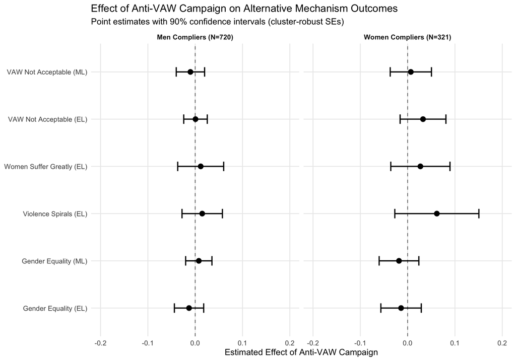

```r
# Outcomes to test for alternative mechanisms
alt_outcomes <- list(
  list(var = "violence_disapproval_ml", label = "VAW Not Acceptable (ML)", wave = "Midline"),
  list(var = "violence_disapproval",    label = "VAW Not Acceptable (EL)", wave = "Endline"),
  list(var = "empathy_pair",            label = "Women Suffer Greatly (EL)", wave = "Endline"),
  list(var = "spiral_risk",             label = "Violence Spirals (EL)", wave = "Endline"),
  list(var = "support_gender_equality_ml", label = "Gender Equality (ML)", wave = "Midline"),
  list(var = "support_gender_equality",    label = "Gender Equality (EL)", wave = "Endline")
)

# Function to get coefficients for the coefficient plot
get_alt_effects <- function(data, gender_label) {
  results <- lapply(alt_outcomes, function(o) {
    res <- run_ols(o$var, data = data)
    data.frame(
      outcome = o$label,
      estimate = res$estimate,
      se = res$se,
      lower90 = res$estimate - 1.645 * res$se,
      upper90 = res$estimate + 1.645 * res$se,
      gender = gender_label,
      stringsAsFactors = FALSE
    )
  })
  do.call(rbind, results)
}

effects_women <- get_alt_effects(women_compliers,
                                 paste0("Women Compliers (N=", nrow(women_compliers), ")"))
effects_men   <- get_alt_effects(men_compliers,
                                 paste0("Men Compliers (N=", nrow(men_compliers), ")"))
effects_all   <- rbind(effects_women, effects_men)

# Reorder outcomes for display
effects_all$outcome <- factor(effects_all$outcome,
                              levels = rev(sapply(alt_outcomes, `[[`, "label")))

ggplot(effects_all, aes(x = outcome, y = estimate)) +
  geom_hline(yintercept = 0, linetype = "dashed", color = "gray50") +
  geom_errorbar(aes(ymin = lower90, ymax = upper90), width = 0.2, linewidth = 0.8) +
  geom_point(size = 3) +
  coord_flip() +
  facet_wrap(~ gender, ncol = 2) +
  labs(
    title = "Effect of Anti-VAW Campaign on Alternative Mechanism Outcomes",
    subtitle = "Point estimates with 90% confidence intervals (cluster-robust SEs)",
    x = NULL,
    y = "Estimated Effect of Anti-VAW Campaign"
  ) +
  ylim(-0.2, 0.2) +
  theme_minimal(base_size = 12) +
  theme(
    strip.text = element_text(face = "bold"),
    panel.grid.minor = element_blank()
  )
```

**Comparison with CPS Figure 5**: The paper shows that all 90% confidence intervals include zero for both genders across all attitude measures. Our replication confirms this crucial null finding: the campaign had **no detectable effect on attitudes** — neither on the acceptability of violence, empathy for victims, awareness of escalation risk, nor support for gender equality. This rules out “attitude change” as the causal mechanism and supports the paper’s argument that the campaign works through a different channel — specifically, by reducing barriers to *reporting* (i.e., alleviating fears of social sanctions for speaking up, as confirmed in Table 3).

# 9 Check this 👆🏻

# 10 Extension: Causal Forest Analysis

## 10.1 Motivation

The paper examines treatment effect heterogeneity in a limited way: it tests whether effects differ by socioeconomic status (using a factor-analytic SES index) and by gender (by running separate regressions). However, **causal forests** (Athey, Tibshirani & Wager, 2019) offer a principled, data-driven approach to discovering heterogeneity across *many* dimensions simultaneously, without requiring pre-specification of which variables moderate treatment effects.

We apply causal forests to:

1. Estimate **individual-level conditional average treatment effects** (CATEs) for the reporting willingness outcome.
2. Identify which **baseline characteristics** are the strongest predictors of treatment effect heterogeneity.
3. Compare these data-driven findings to the paper’s pre-specified subgroup analyses.

## 10.2 Data Preparation

We use the complier panel with midline (pre-treatment) covariates as features. The outcome is the composite intervention index (average willingness to report across four channels).

```r
# Prepare features from midline (pre-treatment) covariates
X_vars <- c(
  "female",
  "age_ml",
  "married_ml",
  "household_head_ml",
  "members_ml",
  "number_children_ml",
  "highest_grade_ml",
  "radio_ml",
  "tv_ml",
  "cellphone_ml",
  "christian_only_ml",
  "muslim_ml",
  "living_standard_ml",
  "violence_disapproval_ml",
  "intervene_index_ml",
  "asset_index",
  "n_end_mean"
)

# Only keep features that exist in the data
X_vars <- X_vars[X_vars %in% names(compliers)]
cat("Features available:", length(X_vars), "\n")
```

```
## Features available: 17
```

```r
cat("Features used:", paste(X_vars, collapse = ", "), "\n")
```

```
## Features used: female, age_ml, married_ml, household_head_ml, members_ml, number_children_ml, highest_grade_ml, radio_ml, tv_ml, cellphone_ml, christian_only_ml, muslim_ml, living_standard_ml, violence_disapproval_ml, intervene_index_ml, asset_index, n_end_mean
```

```r
# Outcome and treatment
Y <- compliers$intervene_index
W <- compliers$IPV
X <- compliers[, X_vars]
clusters_cf <- compliers$tc_id

# Handle missing values (grf requires complete cases)
complete_idx <- complete.cases(Y, W, X)
cat("\nComplete cases:", sum(complete_idx), "out of", length(complete_idx), "\n")
```

```
##
## Complete cases: 1041 out of 1041
```

```r
Y_cf <- Y[complete_idx]
W_cf <- W[complete_idx]
X_cf <- as.matrix(X[complete_idx, ])
clusters_cf <- clusters_cf[complete_idx]
compliers_cf <- compliers[complete_idx, ]
```

## 10.3 Causal Forest Estimation

```r
# Fit causal forest with clustering at the village level
cf <- causal_forest(
  X = X_cf,
  Y = Y_cf,
  W = W_cf,
  clusters = clusters_cf,
  num.trees = 4000,
  seed = 12345
)

# Average treatment effect from the forest
ate_cf <- average_treatment_effect(cf)
cat("Causal Forest ATE:", round(ate_cf[1], 4),
    "(SE:", round(ate_cf[2], 4), ")\n")
```

```
## Causal Forest ATE: 0.05 (SE: 0.0199 )
```

```r
# For comparison: simple OLS ATE
ate_ols <- run_ols("intervene_index", data = compliers_cf)
cat("OLS ATE:", round(ate_ols$estimate, 4),
    "(SE:", round(ate_ols$se, 4), ")\n")
```

```
## OLS ATE: 0.0639 (SE: 0.0203 )
```

The causal forest’s ATE estimate should be close to the OLS estimate, providing a consistency check.

## 10.4 Variable Importance

Which baseline characteristics are the strongest predictors of who benefits most (or least) from the campaign?

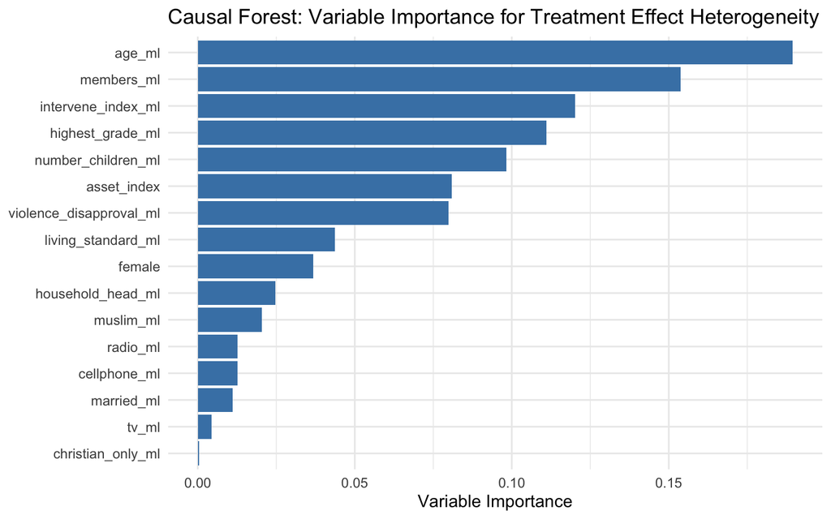

```r
vimp <- variable_importance(cf)
vimp_df <- data.frame(
  Variable = X_vars,
  Importance = as.numeric(vimp)
) %>%
  arrange(desc(Importance))

ggplot(vimp_df, aes(x = reorder(Variable, Importance), y = Importance)) +
  geom_col(fill = "steelblue") +
  coord_flip() +
  labs(
    title = "Causal Forest: Variable Importance for Treatment Effect Heterogeneity",
    x = NULL,
    y = "Variable Importance"
  ) +
  theme_minimal(base_size = 12)
```

```r
kable(vimp_df, digits = 4,
      caption = "Variable Importance Scores (Causal Forest)") %>%
  kable_styling(bootstrap_options = c("striped", "hover"), full_width = FALSE)
```

Variable Importance Scores (Causal Forest)

| Variable | Importance |
| --- | --- |
| age_ml | 0.1894 |
| members_ml | 0.1538 |
| intervene_index_ml | 0.1202 |
| highest_grade_ml | 0.1110 |
| number_children_ml | 0.0983 |
| asset_index | 0.0808 |
| violence_disapproval_ml | 0.0798 |
| living_standard_ml | 0.0436 |
| female | 0.0367 |
| household_head_ml | 0.0247 |
| muslim_ml | 0.0205 |
| radio_ml | 0.0127 |
| cellphone_ml | 0.0126 |
| married_ml | 0.0111 |
| tv_ml | 0.0043 |
| christian_only_ml | 0.0004 |

**Interpretation**: The variable importance scores reveal which baseline characteristics most strongly predict *variation* in treatment effects. High-importance variables suggest dimensions along which the campaign’s impact is heterogeneous.

## 10.5 CATE Distribution

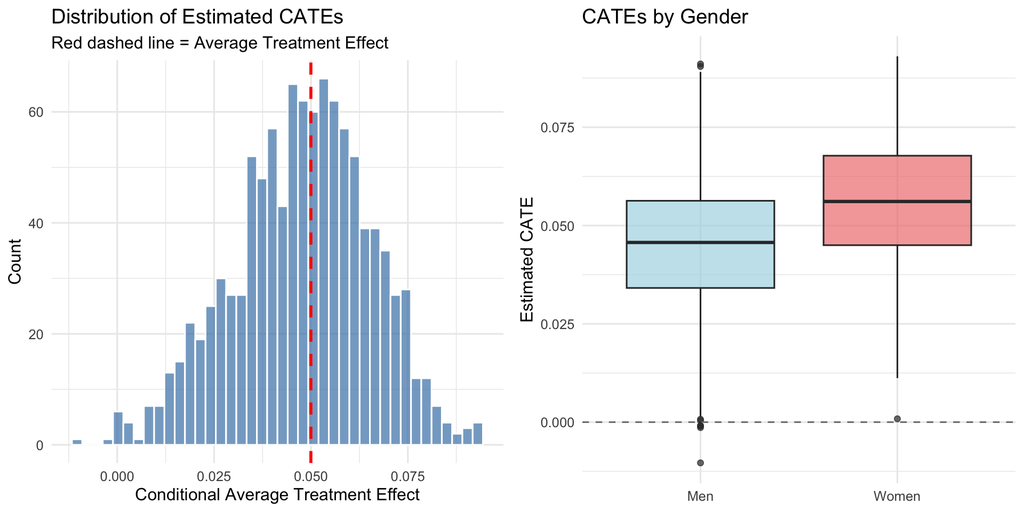

```r
# Predict individual-level CATEs
cate_pred <- predict(cf)$predictions

# Add to data for analysis
compliers_cf$cate <- cate_pred

# Distribution of CATEs
p1 <- ggplot(data.frame(cate = cate_pred), aes(x = cate)) +
  geom_histogram(bins = 40, fill = "steelblue", alpha = 0.7, color = "white") +
  geom_vline(xintercept = ate_cf[1], linetype = "dashed", color = "red", linewidth = 1) +
  labs(
    title = "Distribution of Estimated CATEs",
    subtitle = "Red dashed line = Average Treatment Effect",
    x = "Conditional Average Treatment Effect",
    y = "Count"
  ) +
  theme_minimal(base_size = 12)

# CATEs by gender
p2 <- ggplot(compliers_cf, aes(x = factor(female, labels = c("Men", "Women")),
                                y = cate)) +
  geom_boxplot(fill = c("lightblue", "lightcoral"), alpha = 0.7) +
  geom_hline(yintercept = 0, linetype = "dashed", color = "gray50") +
  labs(
    title = "CATEs by Gender",
    x = NULL,
    y = "Estimated CATE"
  ) +
  theme_minimal(base_size = 12)

# Display plots side by side
gridExtra::grid.arrange(p1, p2, ncol = 2)
```

```r
# Summary statistics of CATEs
cate_summary <- compliers_cf %>%
  group_by(Gender = factor(female, labels = c("Men", "Women"))) %>%
  summarise(
    N = n(),
    Mean_CATE = mean(cate),
    Median_CATE = median(cate),
    SD_CATE = sd(cate),
    Min_CATE = min(cate),
    Max_CATE = max(cate),
    .groups = "drop"
  )

kable(cate_summary, digits = 4,
      caption = "CATE Summary Statistics by Gender") %>%
  kable_styling(bootstrap_options = c("striped", "hover"), full_width = FALSE)
```

CATE Summary Statistics by Gender

| Gender | N | Mean_CATE | Median_CATE | SD_CATE | Min_CATE | Max_CATE |
| --- | --- | --- | --- | --- | --- | --- |
| Men | 720 | 0.0446 | 0.0457 | 0.0172 | -0.0104 | 0.0911 |
| Women | 321 | 0.0552 | 0.0561 | 0.0165 | 0.0008 | 0.0930 |

## 10.6 Best Linear Projection

The best linear projection (BLP) tests whether the CATEs vary systematically with observable characteristics, providing a formal test of heterogeneity.

```r
# Test for heterogeneity: calibration test
calibration <- test_calibration(cf)
cat("Calibration Test Results:\n")
```

```
## Calibration Test Results:
```

```r
print(calibration)
```

```
##
## Best linear fit using forest predictions (on held-out data)
## as well as the mean forest prediction as regressors, along
## with one-sided heteroskedasticity-robust (HC3) SEs:
##
##                                Estimate Std. Error t value  Pr(>t)
## mean.forest.prediction          1.03265    0.39202  2.6342 0.00428 **
## differential.forest.prediction -2.87015    0.97652 -2.9391 0.99832
## ---
## Signif. codes:  0 '***' 0.001 '**' 0.01 '*' 0.05 '.' 0.1 ' ' 1
```

```r
# Best linear projection onto key covariates
blp_result <- best_linear_projection(cf, A = X_cf)
cat("\nBest Linear Projection of CATEs:\n")
```

```
##
## Best Linear Projection of CATEs:
```

```r
print(blp_result)
```

```
##
## Best linear projection of the conditional average treatment effect.
## Confidence intervals are cluster- and heteroskedasticity-robust (HC3):
##
##                            Estimate  Std. Error t value Pr(>|t|)
## (Intercept)              0.06661352  0.12731972  0.5232  0.60095
## female                   0.03878179  0.05774581  0.6716  0.50199
## age_ml                   0.00027403  0.00290115  0.0945  0.92477
## married_ml               0.01236275  0.03758056  0.3290  0.74225
## household_head_ml        0.00090492  0.05636426  0.0161  0.98719
## members_ml               0.00479245  0.00874118  0.5483  0.58363
## number_children_ml      -0.01164262  0.00817268 -1.4246  0.15458
## highest_grade_ml        -0.00232950  0.00555119 -0.4196  0.67484
## radio_ml                -0.02922314  0.04910649 -0.5951  0.55191
## tv_ml                   -0.00182072  0.05021744 -0.0363  0.97108
## cellphone_ml             0.00492325  0.04689815  0.1050  0.91641
## christian_only_ml        0.23973210  0.10919467  2.1955  0.02835 *
## muslim_ml                0.07203517  0.04246008  1.6965  0.09009 .
## living_standard_ml       0.01823947  0.01643324  1.1099  0.26730
## violence_disapproval_ml -0.07666185  0.06715731 -1.1415  0.25392
## intervene_index_ml       0.06428599  0.06143438  1.0464  0.29562
## asset_index              0.03158586  0.13613912  0.2320  0.81658
## ---
## Signif. codes:  0 '***' 0.001 '**' 0.01 '*' 0.05 '.' 0.1 ' ' 1
```

**Interpretation**: The calibration test examines whether the forest’s heterogeneity estimates are meaningful. The “mean.forest.prediction” coefficient tests whether the ATE is non-zero, while the “differential.forest.prediction” coefficient tests whether there is *systematic heterogeneity* — i.e., whether individuals with higher predicted CATEs actually experience larger treatment effects.

## 10.7 Gender-Based Heterogeneity

The paper’s primary heterogeneity analysis splits the sample by gender. We examine whether the causal forest recovers this pattern.

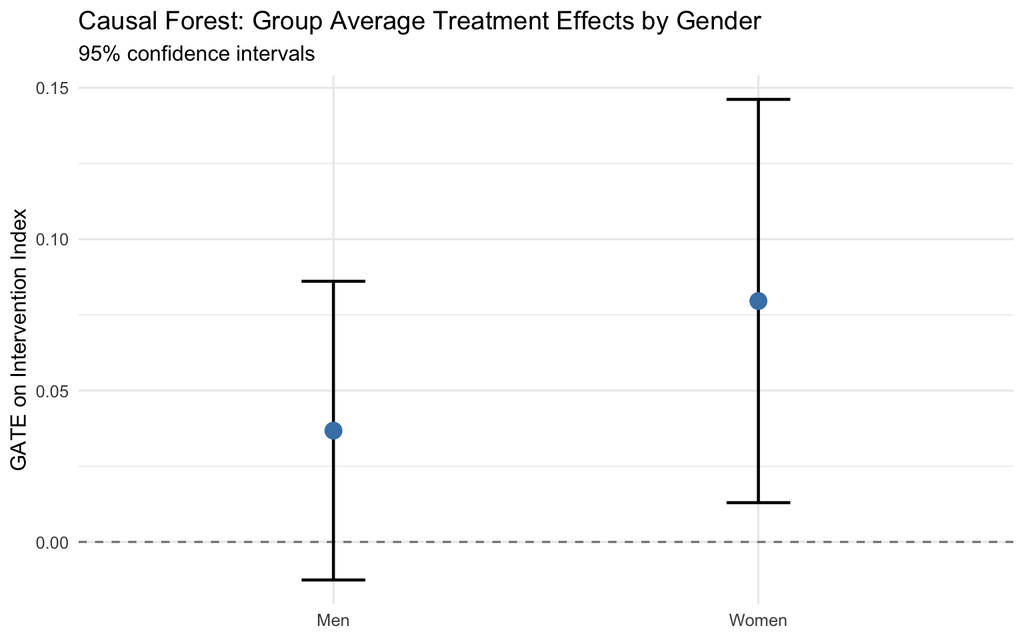

```r
# GATE by gender
ate_women_cf <- average_treatment_effect(cf, subset = compliers_cf$female == 1)
ate_men_cf   <- average_treatment_effect(cf, subset = compliers_cf$female == 0)

gender_ate <- data.frame(
  Gender = c("Women", "Men"),
  ATE = c(ate_women_cf[1], ate_men_cf[1]),
  SE = c(ate_women_cf[2], ate_men_cf[2])
)
gender_ate$lower <- gender_ate$ATE - 1.96 * gender_ate$SE
gender_ate$upper <- gender_ate$ATE + 1.96 * gender_ate$SE

ggplot(gender_ate, aes(x = Gender, y = ATE)) +
  geom_hline(yintercept = 0, linetype = "dashed", color = "gray50") +
  geom_errorbar(aes(ymin = lower, ymax = upper), width = 0.15, linewidth = 0.8) +
  geom_point(size = 4, color = "steelblue") +
  labs(
    title = "Causal Forest: Group Average Treatment Effects by Gender",
    subtitle = "95% confidence intervals",
    x = NULL,
    y = "GATE on Intervention Index"
  ) +
  theme_minimal(base_size = 12)
```

```r
kable(gender_ate, digits = 4,
      caption = "Gender-Specific Average Treatment Effects (Causal Forest)") %>%
  kable_styling(bootstrap_options = c("striped", "hover"), full_width = FALSE)
```

Gender-Specific Average Treatment Effects (Causal Forest)

| Gender | ATE | SE | lower | upper |
| --- | --- | --- | --- | --- |
| Women | 0.0796 | 0.0340 | 0.0130 | 0.1462 |
| Men | 0.0368 | 0.0252 | -0.0126 | 0.0861 |

## 10.8 Heterogeneity by Baseline Reporting Willingness

We examine whether the campaign has different effects on those who were already willing to report at baseline versus those who were not.

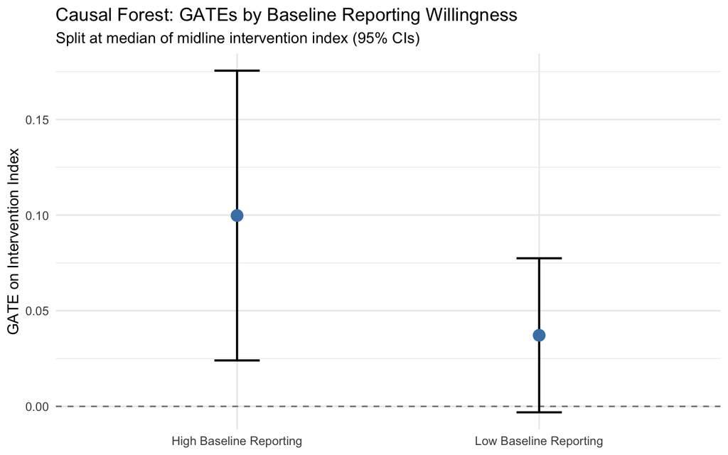

```r
# Split by median baseline reporting willingness
median_baseline <- median(compliers_cf$intervene_index_ml, na.rm = TRUE)
compliers_cf$high_baseline <- as.numeric(compliers_cf$intervene_index_ml > median_baseline)

ate_high <- average_treatment_effect(cf,
              subset = compliers_cf$high_baseline == 1)
ate_low  <- average_treatment_effect(cf,
              subset = compliers_cf$high_baseline == 0)

baseline_ate <- data.frame(
  Group = c("Low Baseline Reporting", "High Baseline Reporting"),
  ATE = c(ate_low[1], ate_high[1]),
  SE = c(ate_low[2], ate_high[2])
)
baseline_ate$lower <- baseline_ate$ATE - 1.96 * baseline_ate$SE
baseline_ate$upper <- baseline_ate$ATE + 1.96 * baseline_ate$SE

ggplot(baseline_ate, aes(x = Group, y = ATE)) +
  geom_hline(yintercept = 0, linetype = "dashed", color = "gray50") +
  geom_errorbar(aes(ymin = lower, ymax = upper), width = 0.15, linewidth = 0.8) +
  geom_point(size = 4, color = "steelblue") +
  labs(
    title = "Causal Forest: GATEs by Baseline Reporting Willingness",
    subtitle = "Split at median of midline intervention index (95% CIs)",
    x = NULL,
    y = "GATE on Intervention Index"
  ) +
  theme_minimal(base_size = 12)
```

```r
kable(baseline_ate, digits = 4,
      caption = "Treatment Effects by Baseline Reporting Willingness") %>%
  kable_styling(bootstrap_options = c("striped", "hover"), full_width = FALSE)
```

Treatment Effects by Baseline Reporting Willingness

| Group | ATE | SE | lower | upper |
| --- | --- | --- | --- | --- |
| Low Baseline Reporting | 0.0372 | 0.0205 | -0.0031 | 0.0774 |
| High Baseline Reporting | 0.0998 | 0.0387 | 0.0240 | 0.1755 |

## 10.9 Heterogeneity by Socioeconomic Status

The paper tests whether effects vary by SES (using a factor-analytic index). We replicate this using the causal forest.

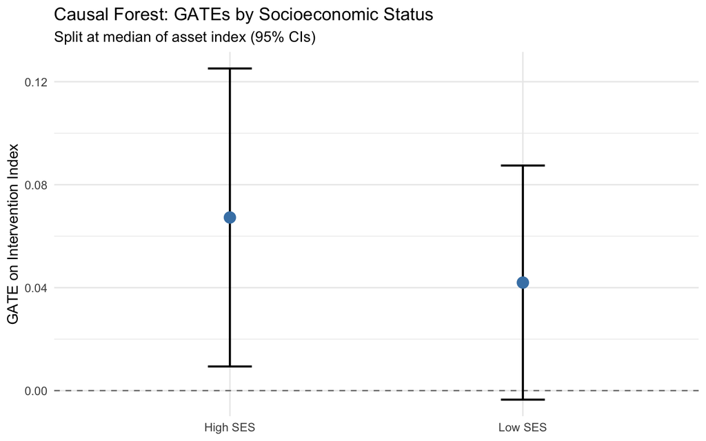

```r
# Use the asset_index as a proxy for SES
median_asset <- median(compliers_cf$asset_index, na.rm = TRUE)
compliers_cf$high_ses <- as.numeric(compliers_cf$asset_index > median_asset)

ate_high_ses <- average_treatment_effect(cf, subset = compliers_cf$high_ses == 1)
ate_low_ses  <- average_treatment_effect(cf, subset = compliers_cf$high_ses == 0)

ses_ate <- data.frame(
  Group = c("Low SES", "High SES"),
  ATE = c(ate_low_ses[1], ate_high_ses[1]),
  SE = c(ate_low_ses[2], ate_high_ses[2])
)
ses_ate$lower <- ses_ate$ATE - 1.96 * ses_ate$SE
ses_ate$upper <- ses_ate$ATE + 1.96 * ses_ate$SE

ggplot(ses_ate, aes(x = Group, y = ATE)) +
  geom_hline(yintercept = 0, linetype = "dashed", color = "gray50") +
  geom_errorbar(aes(ymin = lower, ymax = upper), width = 0.15, linewidth = 0.8) +
  geom_point(size = 4, color = "steelblue") +
  labs(
    title = "Causal Forest: GATEs by Socioeconomic Status",
    subtitle = "Split at median of asset index (95% CIs)",
    x = NULL,
    y = "GATE on Intervention Index"
  ) +
  theme_minimal(base_size = 12)
```

```r
kable(ses_ate, digits = 4,
      caption = "Treatment Effects by Socioeconomic Status") %>%
  kable_styling(bootstrap_options = c("striped", "hover"), full_width = FALSE)
```

Treatment Effects by Socioeconomic Status

| Group | ATE | SE | lower | upper |
| --- | --- | --- | --- | --- |
| Low SES | 0.0420 | 0.0232 | -0.0035 | 0.0875 |
| High SES | 0.0673 | 0.0295 | 0.0094 | 0.1251 |

## 10.10 Causal Forest on Victimization (Women Only)

We also estimate a causal forest for the victimization outcome (any violence), which is the policy-relevant outcome.

```r
# Prepare data for women compliers only
Y_vict <- women_compliers$any_violence
W_vict <- women_compliers$IPV
X_vict_vars <- X_vars[X_vars != "female"]  # Remove female (constant in this sample)
X_vict_vars <- X_vict_vars[X_vict_vars %in% names(women_compliers)]
X_vict <- women_compliers[, X_vict_vars]
clusters_vict <- women_compliers$tc_id

complete_vict <- complete.cases(Y_vict, W_vict, X_vict)
cat("Women compliers with complete data:", sum(complete_vict), "\n")
```

```
## Women compliers with complete data: 321
```

```r
if (sum(complete_vict) > 50) {
  cf_vict <- causal_forest(
    X = as.matrix(X_vict[complete_vict, ]),
    Y = Y_vict[complete_vict],
    W = W_vict[complete_vict],
    clusters = clusters_vict[complete_vict],
    num.trees = 4000,
    seed = 12345
  )

  ate_vict_cf <- average_treatment_effect(cf_vict)
  cat("Causal Forest ATE (Any Violence, Women):", round(ate_vict_cf[1], 4),
      "(SE:", round(ate_vict_cf[2], 4), ")\n")

  # Variable importance
  vimp_vict <- variable_importance(cf_vict)
  vimp_vict_df <- data.frame(
    Variable = X_vict_vars,
    Importance = as.numeric(vimp_vict)
  ) %>%
    arrange(desc(Importance))

  ggplot(vimp_vict_df, aes(x = reorder(Variable, Importance), y = Importance)) +
    geom_col(fill = "coral") +
    coord_flip() +
    labs(
      title = "Causal Forest (Victimization): Variable Importance",
      subtitle = "Outcome = Any Violence (Women Compliers)",
      x = NULL, y = "Variable Importance"
    ) +
    theme_minimal(base_size = 12)

  # Calibration
  cat("\nCalibration test (Victimization):\n")
  print(test_calibration(cf_vict))
} else {
  cat("Insufficient complete cases for causal forest on victimization.\n")
}
```

```
## Causal Forest ATE (Any Violence, Women): -0.1219 (SE: 0.0504 )
##
## Calibration test (Victimization):
##
## Best linear fit using forest predictions (on held-out data)
## as well as the mean forest prediction as regressors, along
## with one-sided heteroskedasticity-robust (HC3) SEs:
##
##                                Estimate Std. Error t value   Pr(>t)
## mean.forest.prediction          0.97713    0.39417  2.4789 0.006847 **
## differential.forest.prediction  0.29079    1.29093  0.2253 0.410961
## ---
## Signif. codes:  0 '***' 0.001 '**' 0.01 '*' 0.05 '.' 0.1 ' ' 1
```

# 11 Conclusion

## 11.2 Extension: Causal Forest Findings

The causal forest analysis adds value in several ways:

## 11.3 Notes on Methodology

- **P-values**: Our p-values use asymptotic cluster-robust standard errors (two-sided). The paper uses **randomization inference** (RI) p-values via 1000+ permutations of treatment assignment within blocks. RI p-values may differ, especially where the paper uses one-sided tests matching directional hypotheses (e.g., lower-tailed for social sanctions, upper-tailed for reporting).
- **LASSO covariates**: Reporting attitude regressions (Tables 1 & 2) use LASSO-selected covariates for precision. Small differences in covariate selection may cause minor numerical discrepancies.
- **SE computation**: We use `sandwich::vcovCL` instead of the original `multiwayvcov::cluster.vcov`. These should produce equivalent results.

## 11.4 Limitations

- **Small sample sizes**: With approximately 300-700 compliers per gender, the power to detect heterogeneous effects is limited.
- **Cluster assignment**: Treatment is assigned at the village level (112 clusters), constraining the effective sample size for cluster-level inference.
- **Complier analysis**: Results are estimated for the subset of individuals who attended screenings, potentially limiting external validity.
- **Causal forest precision**: The relatively small sample size and limited number of clusters means the causal forest estimates may be noisy, particularly for the victimization outcome.